# Funding the War in Ukraine

- Show All Code
- Hide All Code
- View Source

How Western Funding Influenced the War in Ukraine

Author

Bogdan Bunea, Ian Milko, Collin Schwab, and Rayyan Hussien

Published

October 29, 2023

# Research Question

What link exists between the amount of foreign military aid to Ukraine and military personnel and equipment losses for both sides.

Through this question, we aim to assess how foreign add has affected Ukrainian and Russain casualties. We also plan to compare how land has changed hands since the introduction of Western aid.

# Data Sources

1. https://www.kaggle.com/datasets/febinphilips/us-weapons-export-dataset

The above dataset provides the USA’s arms and weapons sales data to different countries from 1996 - 2022. The creator of the dataset does not list the their sources, so the dataset is suspect. However, different news sources do corroborate the data set, so we are confident enough to use the data set.

2. https://www.kaggle.com/datasets/piterfm/2022-ukraine-russian-war

The above dataset describes equipment losses, personnel casualties, and POWs of the Russians in 2022 in the war in Ukraine. This data was compiled from the Ukrainian Defence Ministry, Oryxspioenkop, and different interactive maps. Oryxpioenkop is a common source for Ukraine War related statistics on the internet. It is important to remember that most if not all statistics regarding the war will be tainted by attempts of propoganda by both sides and a fog of war that will make it nearly impossible to determine with 100% accuracy the veracity of this data.

3. https://github.com/leedrake5/Russia-Ukraine/tree/main/data/byType

Using Oryx’s site, github user leedrake5 compiled the above information to use to visualzie Russia’s equipment losses. It is important to remember that most if not all statistics regarding the war will be tainted by attempts of propoganda by both sides and are obscured by a fog of war that will make it nearly impossible to determine the veracity of this data.

4. https://www.ifw-kiel.de/publications/ukraine-support-tracker-data-20758/

The above data is a listing of foreign aid sent to Ukraine. This is split between military, humanitarian, and financial aid. The source of this document is the Kiel Institute for the World Economy, which operates in part as an academic publisher. This information should be seen as trustworthy, as it is taken from statements of the donor countries themselves as they give aid. It should be taken with a slight grain of salt, however, as the donation of greater funds can be used propogandistically to make the donor country look better.

# Proposal Expectations

Around this time in September 2022, you begin to see large amounts of “heavy equipment” being delivered to Ukraine, such as: Belgium delivering 40 Armored Personnel Carriers, Germany delivering 46 Anti-Air Weapons, Artillery from Lithuania, 600 rockets from Luxembourg, and many more. This is just a small set of “heavy” arms deliveries from relatively minor nations (excluding Germany) and from September onwards delivery of heavy weapon systems only increased.

We believe that there is evidence that western weapons have made an impact on Russian casualties throughout the war, and further on into this report we will look deeper into specific battles; specifically the Ukrainian counter offensive to see if Ukrainian casualties have a lower slope than Russian offensives that occurred earlier in the war.

# Preliminary Charts

## Chart 1: Foreign Military Aid to Ukraine

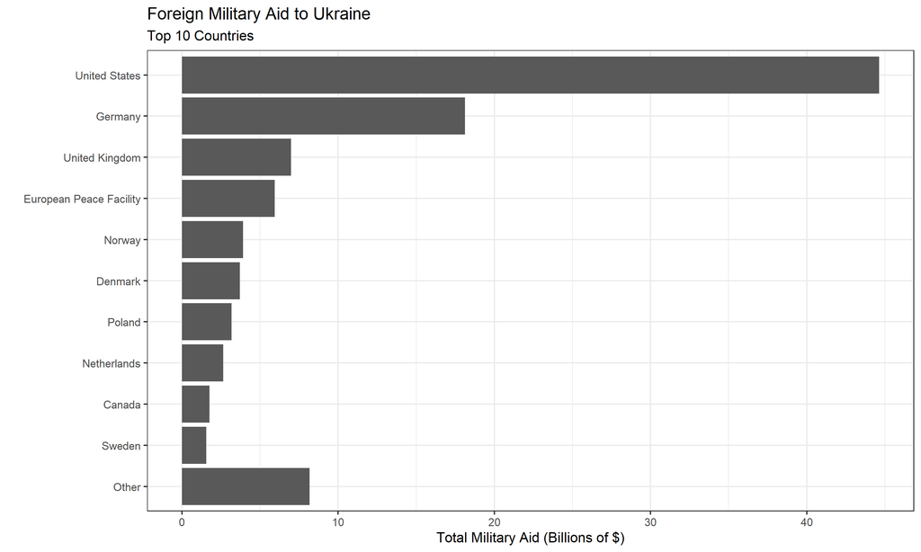

```r
aid <- read.csv(here('data_raw','World Wide Aid.csv'))

aid_tib <- aid %>%
    tibble() %>%
    clean_names() %>%
    select(!c(contains(c('x', 'dummy', 'in_kind')), 'items')) %>%
    rename(monetary_value_source = monetary_value_as_given_by_source) %>%
    select(countries, type_of_aid_general, total_in_usd) %>%
    mutate(total_usd = parse_number(total_in_usd)) %>%
    filter(!is.na(total_usd)) %>%
    filter(type_of_aid_general == "Military") %>%
    group_by(countries) %>%
    summarize(total_by_country = sum(total_usd))

top_categories <- aid_tib %>%
    arrange(desc(total_by_country)) %>%
    top_n(10, wt = total_by_country) %>%
    pull(countries)

aid_tib <- aid_tib %>%
    mutate(countries = fct_other(countries, keep = top_categories, other_level = "Other"))

aid_plot <- aid_tib %>%
    ggplot() +
    geom_col(
        aes(
            x = total_by_country / 10^9,
            y = reorder(countries, total_by_country)
            )) +
    labs(x = "Total Military Aid (Billions of $)", y = "", title = "Foreign Military Aid to Ukraine", subtitle = "Top 10 Countries")+
    theme_bw()
aid_plot
```

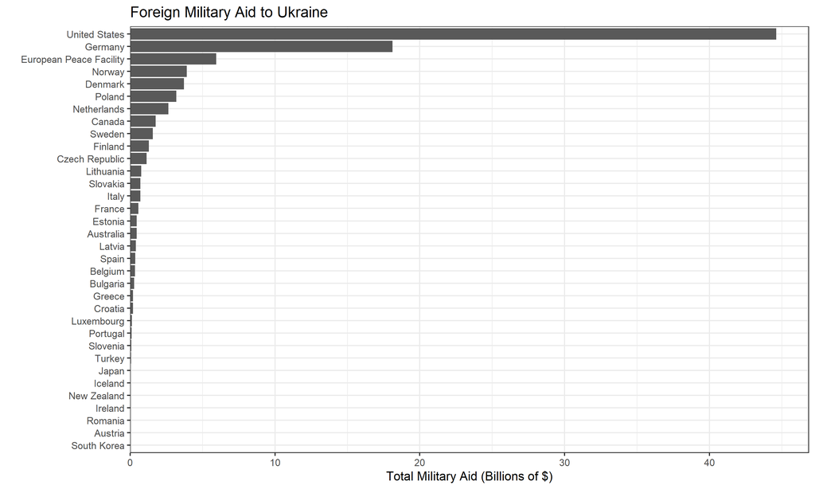

```r
aid1 <- aid %>%
    filter(Type.of.Aid.General == "Military") %>%
    select(Countries, Original.Currency,Type.of.Aid.General, Monetary.Value.as.Given.by.Source, Total, Converted.Value.in.EUR, Total.monetary.value.delivered.in.EUR, Total_in_USD) %>%
    filter(Total != "") %>%
    filter(Total != ".") %>%
    group_by(Countries) %>%
    mutate(Total_in_USD = as.double(Total_in_USD)) %>%
    mutate(Total_by_Country = sum(Total_in_USD)) %>%
    ungroup()
aid2 <- aid1 %>%
    select(Countries, Total_by_Country) %>%
    slice(1, 13, 14,28,31,56,63,91,103,113,125,131,145,149,150,157,161,165,170,189,196,206,213,221,227,237,240,242,254,258,271,284,299,307)
aid2 %>%
    mutate(Total_by_Country = Total_by_Country / 10^9) %>%
    mutate(Countries = fct_reorder(Countries, Total_by_Country)) %>%
    ggplot()+
    geom_col(aes(x = Total_by_Country, y = Countries)) +
    labs(x = "Total Military Aid (Billions of $)", y = "", title = "Foreign Military Aid to Ukraine")+
    theme_bw()+
    scale_x_continuous(expand = expansion(mult = c(0, 0.05)))
```

## Chart 2: Ukrainian and Russian Equipment Casualties

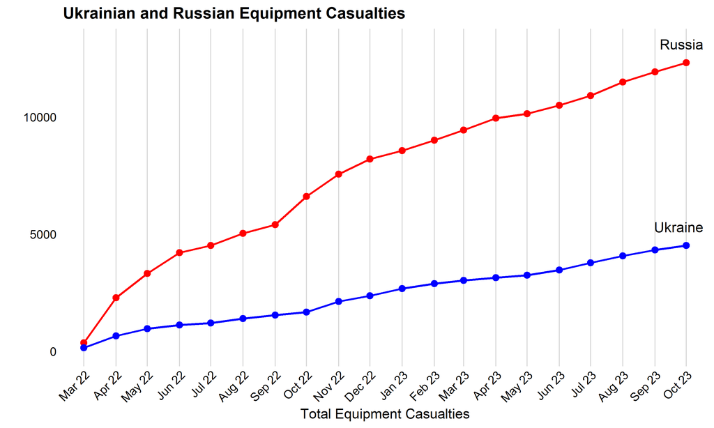

```r
cas <- read.csv(here('data_raw','Total_Cas.csv'))
cas1 <- cas %>%
    mutate(color = (country == "Russia")) %>%
    group_by(country)

cas1 %>%
    mutate(date = mdy(Date)) %>%
    ungroup() %>%
    ggplot(aes(x = date, y = type_total)) +
    geom_point(aes(color = country), size = 3) +
    geom_line(aes(color = country), linewidth = 1) +
    geom_text_repel(
        data = cas1 %>%
            filter(type_total == max(type_total)),
        aes(x = mdy(Date), y = type_total, label = country),
        nudge_y = 800,
        size = 5,
        segment.color = NA
        ) +
    scale_color_manual(values = c('red', 'blue')) +
    scale_x_date(guide = guide_axis(angle = 45),
        expand = expansion(add = c(20, 20)),
        date_labels = "%b %y",
        date_breaks = '1 month') +
    labs(
        x = "Total Equipment Casualties",
        y = "",
        title = "Ukrainian and Russian Equipment Casualties"
        ) +
    theme_minimal_vgrid() +
    theme(
        legend.position = 'none',
        axis.line.y = element_blank(),
        axis.ticks.y = element_blank()
    )
```

# Data Dictionary

## Aid (World Wide Aid.csv)

- **ID:** Identification code for each line item.
- **Countries:** The donating country.
- **Announcement Date:** The date the aid was announced.
- **Type of Aid General:** The type of aid granted; either humanitarian, financial, or military.
- **Type of Aid Specific:** A more specific description of the aid granted.
- **Explanation:** An explanation of the aid from the data sets authors perspective.
- **Original Currency:** The currency in which the aid was given.
- **Monetary Value as Given by Source:** The monetary value of the aid as announced by the donor.
- **Items:** A list of the donated items if not strictly currency.
- **Type of Item:** Further classification of donated items for filtering purposes.
- **Sub-type of Item:** Even further classification of donated items for filtering purposes.
- **No. of Units:** Number of units (as detailed in the items column) announced for donation.
- **No. of Units Delivered (in-kind military aid):** Actual number of units delivered.
- **Unit Price in USD:** Price of 1 item in US dollars.
- **Total:** Total monetary value of aid in the original currency.
- **Converted Value in EUR:** Total monetary value of pledged aid in euros.
- **Total Monetary Value Delivered in EUR:** Total monetary value of delivered aid in euros.
- **Official Source:** Says whether there is an official for the aid announcement.
- **Source of Aid 1:** News source or statement from donor country detailing the aid.
- **Source of Aid 2:** News source or statement from donor country detailing the aid.
- **Source of Aid 3:** News source or statement from donor country detailing the aid.
- **Source of Aid 4:** News source or statement from donor country detailing the aid.
- **Bilateral loan/grant made through IMF or WB?:** Lists whether the aid is a donation or grant from the International Monetary Fund or World Bank (0 for false, 1 for true).
- **Updated/newly added entry:** Lists whether the entry was added in the most recent update to the data set (0 for false, 1 for true).
- **Deliveries = Commitments (1=yes, 0=no):** Lists whether the delivered aid matches the commitment.
- **Official delivery source (1=yes, 0=no):** Lists whether there is an official source confirming delivery of the aid.
- **Source for Delivery:** The news source or statement confirming the delivery of the aid.
- **Earmarked year:** The fiscal year in which the aid was to budgeted.
- **Relative importance (2=very important, 1=important, 0=less important):** A subjective rating of the importance of the aid as provided by the data sets authors.
- **Official Source Yes/No Dummy:** A redundant column for the Official Source column.
- **Total_in_USD:** The total aid donated in US Dollars.

## Equipment Casualties (Total_Cas.csv)

- **country:** The country whose equipment casualties are being listed (Russia or Ukraine).
- **equipment_type:** The type of equipment lost.
- **destroyed:** A number showing how many of the designated equipment were destroyed.
- **abandoned:** A number showing how many of the designated equipment were abandoned.
- **captured:** A number showing how many of the designated equipment were captured.
- **damaged:** A number showing how many of the designated equipment were destroyed.
- **type_total:** A cumulative total of the amount of equipment casualties sustained.
- **Date:** The date on which the data set was updated with the row’s information.

## Personnel Casualties (russia_losses_personnel.csv)

- **date:** The date on which the casualties were reported.
- **day:** The day of the war.
- **personnel:** The number of personnel casualties.
- **personnel:** Denotes the accuracy of the previous column.
- **POW:** The number of Prisoners of War taken on the designated day.

## United States Arm Sales (ArmsSales(Kaggle).csv)

- **Country:** Country names
- **Year:** The year the during which the sales occurred.
- **Deliveries:** The total US dollar amount of sales.
- **Authorizations:** The share of deliveries that were commercial sales.
- **Notifications:** The share of deliveries that were foreign military sales.

ALL MEMBERS CONTRIBITED EQUALLY